# Hubert10 😎

# Spis treści

### Wstęp – przykłady szeregów czasowych

- Wykres notowań kursu euro
- Prawo Moore'a
- Ranking najlepszych procesorów
- Warszawska Wyższa Szkoła Informatyki - WYKŁAD INAUGURACYJNY 2015 / 2016

### Python w analizie danych

- 1. Szeregi czasowe (301)
- 11.1. Typy danych i narzędzia przeznaczone do obsługi daty i czasu (302)
- Konwersja pomiędzy obiektami string i datetime (303)
  - datetime -> string
    - funkcja str()
    - metoda strftime()
  - string -> datetime
  - funkcja strptime
  - metoda parser.parse
  - metoda to_datetime

### U.S. Gasoline and Diesel Retail Prices 1995-2021

- Statystyka
- Typy danych i zmiana indeksu
- Dodanie kolumn
- Wykres 1995-2021r
- Wykres 2020r.
- 4 Wykresy (można wyświetlać 'dane.A1' albo 'wykres20.A1')
- Próbkowanie ziarnistości

# Wstęp – przykłady szeregów czasowych

Wiele szeregów czasowych charakteryzuje się **stałą częstotliwością** (poszczególne obserwacje są rejestrowane w równych odstępach czasu np. co 15 sekund).

Szeregi czasowe mogą charakteryzowac się też **zmienną częstotliwością** rejestrowania obserwacji.

### Wykres notowań kursu euro

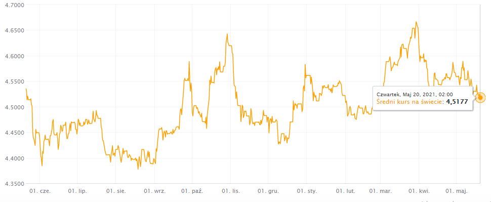

https://www.walutomat.pl/kursy-walut/eur-pln/

### Prawo Moore'a

**Prawo Moore'a** - gęstość upakowania tranzystorów na cal kwadratowy procesora podwaja się co dwa lata

[figure not shown]

"... **obecnie liczba tranzystorów w procesorach ogólnego przeznaczenia wzrasta o 50 procent w skali roku, przy zaledwie 10 procentowej poprawie wydajności tych układów.** Jednak argumentacja opierająca się na wydajności nie obala prawa Moore’a, które nic nie mówi o tym aspekcie, a dotyczy jedynie podwajania liczby tranzystorów." https://www.chip.pl/2017/10/szef-nvidii-koniec-prawa-moorea/ [4 października 2017]

```python
# podwaja się co dwa lata

import math

pierwiastek2 = math.sqrt(2)
print('Pierwiastek z 2 =',pierwiastek2)

poroku = 100 * pierwiastek2
print("\nporoku:", poroku)

za2lata = poroku * pierwiastek2
print("\nza 2 lata:", za2lata)
```

```
Pierwiastek z 2 = 1.4142135623730951

poroku: 141.4213562373095

za 2 lata: 200.00000000000003
```

```python
# jeśli podwaja się co 2 lata to wzrastało o 41% w skali roku

za10latco41 = 100 * pierwiastek2**10
za10latco41
```

```
3200.0000000000023
```

```python
# obecnie wzrasta o 50% w skali roku

za10latco50 = 100 * 1.50**10
za10latco50
```

```
5766.50390625
```

```python
wydajnosc = 100 * 1.10**10
wydajnosc # wzrost wydajności po 10 latach
```

```
259.3742460100002
```

```python
wydajnosc = 100 * 1.10**2
wydajnosc # wzrost wydajności po 2 latach
```

```
121.00000000000001
```

#### https://mfiles.pl/pl/index.php/Prawo_Moore%27a

#### http://zeszyty-naukowe.wwsi.edu.pl/zeszyty/zeszyt13/Ontologia_cyberprzestrzeni.pdf

"tzw. prawo Moore’a, które na podstawie danych empirycznych, prowadziło do wniosków, że co 18 miesięcy podwaja się liczba tranzystorów w układzie scalonym (sformułowana tak w roku 1965 zależność w dziesięć lat później była aktualizowane – co 2 lata, **a w roku 1999 Moore uznał, że dotąd podwajanie będzie następować co 4-5 lat)**;"

### Ranking najlepszych procesorów

https://www.cpubenchmark.net/cpu_list.php

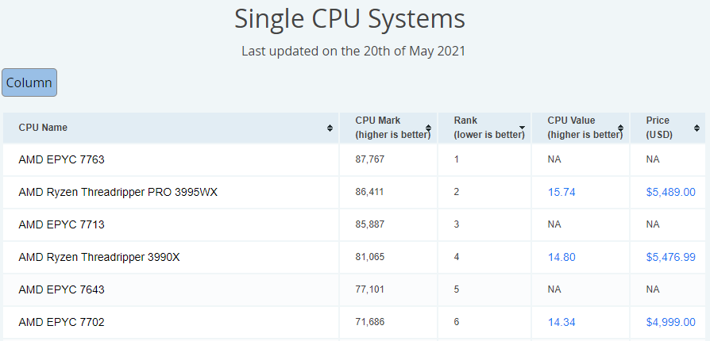

### Warszawska Wyższa Szkoła Informatyki - WYKŁAD INAUGURACYJNY 2015 / 2016

- https://www.youtube.com/watch?v=jp_SOBuOsi0&ab_channel=Ma%C5%82achMa%C5%82achOficjalnykana%C5%82wykonawcy

10:50

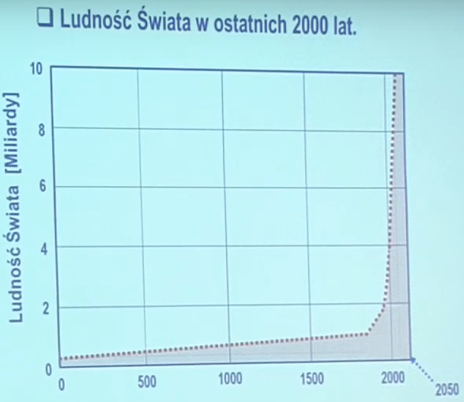

12:40

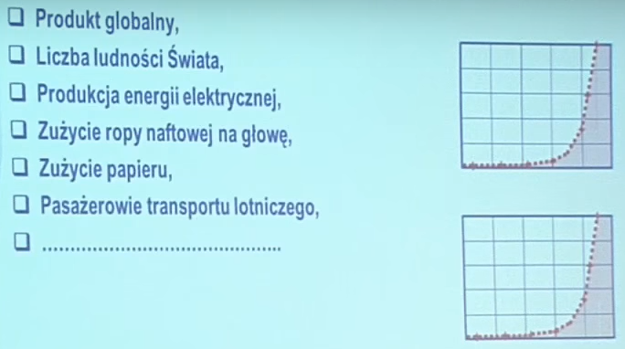

15:00

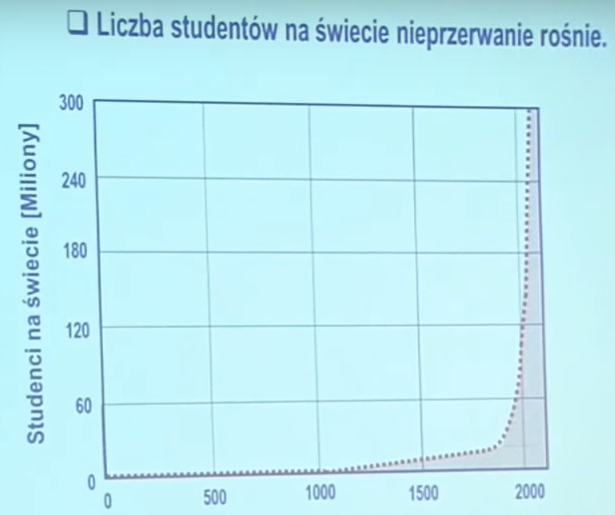

14:35

[figure not shown]

# Python w analizie danych

[figure not shown]

Data wydania książki: 2018-06-15

### Wes McKinney (autor ksiażki) jest autorem biblioteki Pandas w Python

[figure not shown]

### 11. Szeregi czasowe (301)

- 11.1. Typy danych i narzędzia przeznaczone do obsługi daty i czasu (302)
  - Konwersja pomiędzy obiektami string i datetime (303)
- 11.2. Podstawy szeregów czasowych (305)
  - Indeksowanie i wybieranie (306)
  - Szeregi czasowe z duplikatami indeksów (309)
- 11.3. Zakresy dat, częstotliwości i przesunięcia (310)
  - Generowanie zakresów dat (310)
  - Częstotliwości i przesunięcia daty (313)
  - Przesuwanie daty (314)
- 11.4. Obsługa strefy czasowej (317)
  - Lokalizacja i konwersja stref czasowych (317)
  - Operacje z udziałem obiektów Timestamp o wyznaczonej strefie czasowej (319)
  - Operacje pomiędzy różnymi strefami czasowymi (320)
- 11.5. Okresy i przeprowadzanie na nich operacji matematycznych (321)
  - Konwersja częstotliwości łańcuchów (322)
  - Kwartalne częstotliwości okresów (323)
  - Konwersja znaczników czasu na okresy (i z powrotem) (325)
  - Tworzenie obiektów PeriodIndex na podstawie tablic (326)
- 11.6. Zmiana rozdzielczości i konwersja częstotliwości (328)
  - Zmniejszanie częstotliwości (329)
  - Zwiększanie rozdzielczości i interpolacja (332)
  - Zmiana rozdzielczości z okresami (333)
- 11.7. Funkcje ruchomego okna (334)
  - Funkcje ważone wykładniczo (337)
  - Binarne funkcje ruchomego okna (338)
  - Funkcje ruchomego okna definiowane przez użytkownika (340)
- 11.8. Podsumowanie (340)

# Wersja Python

```python
# $ PYTHON

# Autor książki korzysta z wersji Python 3.6.0
```

```python
# Moja wersja Python
from platform import python_version

python_version()
```

```
'3.8.3'
```

# 11. Szeregi czasowe (301)

### Pracując z szeregami czasowymi można spotkać:

- **Znaczniki czasu** - określają czas dokonania obserwacji.
- Stałe **okresy**, takie jak miesiąc (np. styczeń 2007) lub cały rok (np. 2010).
- **Interwały** oznaczone znacznikiem czasu rozpoczęcia i znacznikiem czasu zakończenia.
  - (okresy mozna traktować jako charakterystyczne interwały)
- Szereg czasowy eksperymentu, gdzie każdy znacznik czasu określa czas, który upłynał od określonego momentu (szeregi czasowe mogą np. podawać średnicę pieczonego ciastka w zależności od czasu jego pieczenia).

# 11.1. Typy danych i narzędzia przeznaczone do obsługi daty i czasu (302)

```python
# Najczęściej stosowany typ danych czasowych to *datetime.datetime* lub po prostu *datetime*

from datetime import datetime

teraz = datetime.now()
teraz
```

```
datetime.datetime(2021, 6, 2, 21, 24, 59, 263058)
```

```python
print('Rok:',teraz.year,
      '\nmiesiac:',teraz.month,
      '\ndzień:', teraz.day,
      '\ngodzina', teraz.hour,
      '\nminuta:', teraz.minute,
      '\nsekunda:', teraz.second,
      '\nmikrosekunda:', teraz.microsecond)
```

```
Rok: 2021
miesiac: 6
dzień: 2
godzina 21
minuta: 24
sekunda: 59
mikrosekunda: 263058
```

```python
teraz.date()
```

```
datetime.date(2021, 6, 2)
```

```python
teraz.time()
```

```
datetime.time(21, 24, 59, 263058)
```

```python
roznica = teraz - datetime(2018, 10, 1)

print('Jestem studentem WWSI',roznica.days,'dni')
```

```
Jestem studentem WWSI 975 dni
```

```python
# KOMENTARZ day, days
# porównanie do int i float

z = 5-2 # mogę - + *
print(z)
```

```
3
```

```python
z = 5/2
print(z)
```

```
2.5
```

```python
# x to typ *datatime.timedelta* lub po prostu *timedelta*
# timedelta = datetime - datetime

roznica
```

```
datetime.timedelta(days=975, seconds=77099, microseconds=263058)
```

```python
# timedelta przedstawia różnicę pomiędzy dwoma datami

from datetime import timedelta

jutro = teraz + timedelta(1)
print(jutro)
```

```
2021-06-03 21:24:59.263058
```

```python
wczoraj = teraz - timedelta(1)
print(wczoraj)
```

```
2021-06-01 21:24:59.263058
```

```python
zarok = teraz + timedelta(365)
print(zarok)
```

```
2022-06-02 21:24:59.263058
```

```python
# Przykłady lat przestępnych: 2016, 2020, 2024, 2028 czy 2032

za10lat = teraz + 10 * timedelta(365) + timedelta(2)
print(za10lat)
```

```
2031-06-02 21:24:59.263058
```

#### Tabela 11.1 Typy danych obsługiwane przez moduł datetime

Typ danych - opis

- date - rok, miesiąc, dzień
- time - godzina, minuta, sekunda, mikrosekunda
- datetime - rok, miesiąc, dzień, godzina, minuta, sekunda, mikrosekunda
- timedelta - różnica pomiędzy dwoma wartościami datetime (w postaci dni, **sekund**, mikrosekund)

*** tzinfo - przeznaczony do strefy czasowej

```python
print(teraz)
```

```
2021-06-02 21:24:59.263058
```

3.5 h = 3.5 *60* 60 = 12 600 s

```python
za3ipolh = teraz + timedelta(0,12600,0)
print(za3ipolh)
```

```
2021-06-03 00:54:59.263058
```

### Konwersja pomiędzy obiektami string i datetime (303)

### funkcja str() datetime -> string

```python
datetime(2018,10,1)
```

```
datetime.datetime(2018, 10, 1, 0, 0)
```

```python
data1 = datetime(2018, 10, 1)
str(data1) # funkcja str()
```

```
'2018-10-01 00:00:00'
```

```python
x = str(data1)
print(type(x))
```

```
<class 'str'>
```

```python
x
```

```
'2018-10-01 00:00:00'
```

### metoda strftime() datetime -> string

```python
datetime(2018, 10, 1)
```

```
datetime.datetime(2018, 10, 1, 0, 0)
```

```python
data2 = datetime(2018, 10, 1)
data2.strftime('%Y-%m-%d') # metoda strftime
```

```
'2018-10-01'
```

```python
y = data2.strftime('%Y-%m-%d') # skrót '%F'
print(type(y))
```

```
<class 'str'>
```

```python
y
```

```
'2018-10-01'
```

#### Tabela 11.2 Specyfikatory formatu daty i czasu (kompatybilne z ISO C89)

```python
data3 = datetime(2018, 10, 1)
```

```python
# wartość całkowitoliczbowa określająca dzień tygodnia [0 (niedziela), 6 (sobota)]

z = data3.strftime('%w')
```

```python
print(type(z))
```

```
<class 'str'>
```

```python
z
```

```
'1'
```

### funkcja strptime string -> datetime

```python
value = '2018-10-1'
datetime.strptime(value, '%Y-%m-%d')
```

```
datetime.datetime(2018, 10, 1, 0, 0)
```

```python
datestrs = ['2/10/2018','3/10/2018', '5/10/2018']
[datetime.strptime(daty, '%d/%m/%Y') for daty in datestrs]
```

```
[datetime.datetime(2018, 10, 2, 0, 0),
 datetime.datetime(2018, 10, 3, 0, 0),
 datetime.datetime(2018, 10, 5, 0, 0)]
```

### metoda parser.parse string -> datetime

```python
from dateutil.parser import parse

parse('2018-10-1')
```

```
datetime.datetime(2018, 10, 1, 0, 0)
```

```python
parse('Jan 31, 1997, 10:45 PM') # "Jan" można zmienić na 1
```

```
datetime.datetime(1997, 1, 31, 22, 45)
```

```python
# dzień przed miesiącem

parse('6/12/2011', dayfirst=True)
```

```
datetime.datetime(2011, 12, 6, 0, 0)
```

### metoda to_datetime string -> datetime

```python
import pandas as pd

daty2 = ['2011-07-06 12:00:00', '2011-08-06 12:00:00']
pd.to_datetime(daty2)
```

```
DatetimeIndex(['2011-07-06 12:00:00', '2011-08-06 12:00:00'], dtype='datetime64[ns]', freq=None)
```

```python
daty2 # daty nie zmieniły się na DatetimeIndex, bo nie przypisałem do zmiennej
```

```
['2011-07-06 12:00:00', '2011-08-06 12:00:00']
```

```python
idx = pd.to_datetime(daty2 + [None])
idx
```

```
DatetimeIndex(['2011-07-06 12:00:00', '2011-08-06 12:00:00', 'NaT'], dtype='datetime64[ns]', freq=None)
```

```python
idx[2]
```

```
NaT
```

```python
pd.isnull(idx)
```

```
array([False, False,  True])
```

**Wartością typu null stosowana przez pakiet pandas w danych znacznika czasu jest 'NaT' (z ang. Not a Time)**

- 'Nan'= Not a Number

# U.S. Gasoline and Diesel Retail Prices 1995-2021

źródło danych: https://www.kaggle.com/mruanova/us-gasoline-and-diesel-retail-prices-19952021

```python
import numpy as np
import pandas as pd
import seaborn as sns
import matplotlib.pyplot as plt
```

```python
dane=pd.read_csv('C:\\Users\\V6\Desktop\\Gasoline.csv')
dane
```

|  | Date | A1 | A2 | A3 | R1 | R2 | R3 | M1 | M2 | M3 | P1 | P2 | P3 | D1 |
| --- | --- | --- | --- | --- | --- | --- | --- | --- | --- | --- | --- | --- | --- | --- |
| 0 | 01/02/1995 | 1.127 | 1.104 | 1.231 | 1.079 | 1.063 | 1.167 | 1.170 | 1.159 | 1.298 | 1.272 | 1.250 | 1.386 | 1.104 |
| 1 | 01/09/1995 | 1.134 | 1.111 | 1.232 | 1.086 | 1.070 | 1.169 | 1.177 | 1.164 | 1.300 | 1.279 | 1.256 | 1.387 | 1.102 |
| 2 | 01/16/1995 | 1.126 | 1.102 | 1.231 | 1.078 | 1.062 | 1.169 | 1.168 | 1.155 | 1.299 | 1.271 | 1.249 | 1.385 | 1.100 |
| 3 | 01/23/1995 | 1.132 | 1.110 | 1.226 | 1.083 | 1.068 | 1.165 | 1.177 | 1.165 | 1.296 | 1.277 | 1.256 | 1.378 | 1.095 |
| 4 | 01/30/1995 | 1.131 | 1.109 | 1.221 | 1.083 | 1.068 | 1.162 | 1.176 | 1.163 | 1.291 | 1.275 | 1.255 | 1.370 | 1.090 |
| ... | ... | ... | ... | ... | ... | ... | ... | ... | ... | ... | ... | ... | ... | ... |
| 1356 | 12/28/2020 | 2.330 | 2.225 | 2.535 | 2.243 | 2.158 | 2.423 | 2.634 | 2.482 | 2.858 | 2.889 | 2.770 | 3.031 | 2.635 |
| 1357 | 01/04/2021 | 2.336 | 2.227 | 2.549 | 2.249 | 2.160 | 2.437 | 2.639 | 2.484 | 2.867 | 2.895 | 2.771 | 3.042 | 2.640 |
| 1358 | 01/11/2021 | 2.403 | 2.298 | 2.610 | 2.317 | 2.232 | 2.498 | 2.702 | 2.550 | 2.927 | 2.959 | 2.839 | 3.101 | 2.670 |
| 1359 | 01/18/2021 | 2.464 | 2.351 | 2.688 | 2.379 | 2.285 | 2.579 | 2.759 | 2.601 | 2.995 | 3.014 | 2.885 | 3.166 | 2.696 |
| 1360 | 01/25/2021 | 2.478 | 2.363 | 2.703 | 2.392 | 2.298 | 2.593 | 2.776 | 2.615 | 3.014 | 3.033 | 2.900 | 3.191 | 2.716 |

1361 rows × 14 columns

```
- A1: Weekly U.S. All Grades All Formulations Retail Gasoline Prices (Dollars per Gallon)
- A2: Weekly U.S. All Grades Conventional Retail Gasoline Prices (Dollars per Gallon)
- A3: Weekly U.S. All Grades Reformulated Retail Gasoline Prices (Dollars per Gallon)

- R1: Weekly U.S. Regular All Formulations Retail Gasoline Prices (Dollars per Gallon)
- R2: Weekly U.S. Regular Conventional Retail Gasoline Prices (Dollars per Gallon)
- R3: Weekly U.S. Regular Reformulated Retail Gasoline Prices (Dollars per Gallon)

- M1: Weekly U.S. Midgrade All Formulations Retail Gasoline Prices (Dollars per Gallon)
- M2: Weekly U.S. Midgrade Conventional Retail Gasoline Prices (Dollars per Gallon)
- M3: Weekly U.S. Midgrade Reformulated Retail Gasoline Prices (Dollars per Gallon)

- P1: Weekly U.S. Premium All Formulations Retail Gasoline Prices (Dollars per Gallon)
- P2: Weekly U.S. Premium Conventional Retail Gasoline Prices (Dollars per Gallon)
- P3: Weekly U.S. Premium Reformulated Retail Gasoline Prices (Dollars per Gallon)

- D1: Weekly U.S. No 2 Diesel Retail Prices (Dollars per Gallon)
```

```python
# sprawdzenie NaN
dane.isnull().sum().sum()
```

```
0
```

### Statystyka

```python
dane.describe().style.format("{:.2f}")
```

|  | A1 | A2 | A3 | R1 | R2 | R3 | M1 | M2 | M3 | P1 | P2 | P3 | D1 |
| --- | --- | --- | --- | --- | --- | --- | --- | --- | --- | --- | --- | --- | --- |
| count | 1361.00 | 1361.00 | 1361.00 | 1361.00 | 1361.00 | 1361.00 | 1361.00 | 1361.00 | 1361.00 | 1361.00 | 1361.00 | 1361.00 | 1361.00 |
| mean | 2.29 | 2.23 | 2.40 | 2.23 | 2.18 | 2.33 | 2.38 | 2.32 | 2.51 | 2.52 | 2.47 | 2.61 | 2.40 |
| std | 0.86 | 0.84 | 0.88 | 0.85 | 0.84 | 0.88 | 0.88 | 0.86 | 0.91 | 0.91 | 0.89 | 0.93 | 1.00 |
| min | 0.95 | 0.93 | 1.04 | 0.91 | 0.89 | 0.97 | 1.01 | 0.98 | 1.11 | 1.10 | 1.07 | 1.19 | 0.95 |
| 25% | 1.46 | 1.43 | 1.55 | 1.42 | 1.39 | 1.49 | 1.52 | 1.48 | 1.62 | 1.61 | 1.57 | 1.70 | 1.42 |
| 50% | 2.33 | 2.25 | 2.46 | 2.24 | 2.17 | 2.37 | 2.48 | 2.40 | 2.63 | 2.69 | 2.64 | 2.77 | 2.48 |
| 75% | 2.90 | 2.83 | 3.06 | 2.83 | 2.77 | 2.98 | 3.03 | 2.93 | 3.21 | 3.21 | 3.13 | 3.32 | 3.07 |
| max | 4.17 | 4.10 | 4.30 | 4.11 | 4.05 | 4.25 | 4.23 | 4.15 | 4.39 | 4.34 | 4.28 | 4.46 | 4.76 |

### Typy danych i zmiana indeksu

```python
dane.info()
```

```
<class 'pandas.core.frame.DataFrame'>
RangeIndex: 1361 entries, 0 to 1360
Data columns (total 14 columns):
 #   Column  Non-Null Count  Dtype
---  ------  --------------  -----
 0   Date    1361 non-null   object
 1   A1      1361 non-null   float64
 2   A2      1361 non-null   float64
 3   A3      1361 non-null   float64
 4   R1      1361 non-null   float64
 5   R2      1361 non-null   float64
 6   R3      1361 non-null   float64
 7   M1      1361 non-null   float64
 8   M2      1361 non-null   float64
 9   M3      1361 non-null   float64
 10  P1      1361 non-null   float64
 11  P2      1361 non-null   float64
 12  P3      1361 non-null   float64
 13  D1      1361 non-null   float64
dtypes: float64(13), object(1)
memory usage: 149.0+ KB
```

```python
# Ważną cechą indeksu jest jego unikalność. Pod jednym adresem powinien być tylko jeden rekord.
# Sprawdzam czy kolumna 'Date' zawiera unikalne wartości:
dane.Date.is_unique
```

```
True
```

```python
# Konwertowanie 'Date' z object na datetime
dane['Date'] = pd.to_datetime(dane['Date'])
print(type(dane.Date))
```

```
<class 'pandas.core.series.Series'>
```

```python
# zmieniam indeks
dane = dane.set_index('Date')
dane.head(3)
```

| Date | A1 | A2 | A3 | R1 | R2 | R3 | M1 | M2 | M3 | P1 | P2 | P3 | D1 |
| --- | --- | --- | --- | --- | --- | --- | --- | --- | --- | --- | --- | --- | --- |
| 1995-01-02 | 1.127 | 1.104 | 1.231 | 1.079 | 1.063 | 1.167 | 1.170 | 1.159 | 1.298 | 1.272 | 1.250 | 1.386 | 1.104 |
| 1995-01-09 | 1.134 | 1.111 | 1.232 | 1.086 | 1.070 | 1.169 | 1.177 | 1.164 | 1.300 | 1.279 | 1.256 | 1.387 | 1.102 |
| 1995-01-16 | 1.126 | 1.102 | 1.231 | 1.078 | 1.062 | 1.169 | 1.168 | 1.155 | 1.299 | 1.271 | 1.249 | 1.385 | 1.100 |

### Dodanie kolumn

```python
dane=pd.DataFrame(dane)

dane['rok']=[dane.index[i].year   for i in range(1361)]
dane['miesiac']=[dane.index[i].month  for i in range(1361)]
dane['dzien']=[dane.index[i].day   for i in range(1361)]
dane['Kiedy']=[dane.index[i]   for i in range(1361)]

dane
```

| Date | A1 | A2 | A3 | R1 | R2 | R3 | M1 | M2 | M3 | P1 | P2 | P3 | D1 | rok | miesiac | dzien | Kiedy |
| --- | --- | --- | --- | --- | --- | --- | --- | --- | --- | --- | --- | --- | --- | --- | --- | --- | --- |
| 1995-01-02 | 1.127 | 1.104 | 1.231 | 1.079 | 1.063 | 1.167 | 1.170 | 1.159 | 1.298 | 1.272 | 1.250 | 1.386 | 1.104 | 1995 | 1 | 2 | 1995-01-02 |
| 1995-01-09 | 1.134 | 1.111 | 1.232 | 1.086 | 1.070 | 1.169 | 1.177 | 1.164 | 1.300 | 1.279 | 1.256 | 1.387 | 1.102 | 1995 | 1 | 9 | 1995-01-09 |
| 1995-01-16 | 1.126 | 1.102 | 1.231 | 1.078 | 1.062 | 1.169 | 1.168 | 1.155 | 1.299 | 1.271 | 1.249 | 1.385 | 1.100 | 1995 | 1 | 16 | 1995-01-16 |
| 1995-01-23 | 1.132 | 1.110 | 1.226 | 1.083 | 1.068 | 1.165 | 1.177 | 1.165 | 1.296 | 1.277 | 1.256 | 1.378 | 1.095 | 1995 | 1 | 23 | 1995-01-23 |
| 1995-01-30 | 1.131 | 1.109 | 1.221 | 1.083 | 1.068 | 1.162 | 1.176 | 1.163 | 1.291 | 1.275 | 1.255 | 1.370 | 1.090 | 1995 | 1 | 30 | 1995-01-30 |
| ... | ... | ... | ... | ... | ... | ... | ... | ... | ... | ... | ... | ... | ... | ... | ... | ... | ... |
| 2020-12-28 | 2.330 | 2.225 | 2.535 | 2.243 | 2.158 | 2.423 | 2.634 | 2.482 | 2.858 | 2.889 | 2.770 | 3.031 | 2.635 | 2020 | 12 | 28 | 2020-12-28 |
| 2021-01-04 | 2.336 | 2.227 | 2.549 | 2.249 | 2.160 | 2.437 | 2.639 | 2.484 | 2.867 | 2.895 | 2.771 | 3.042 | 2.640 | 2021 | 1 | 4 | 2021-01-04 |
| 2021-01-11 | 2.403 | 2.298 | 2.610 | 2.317 | 2.232 | 2.498 | 2.702 | 2.550 | 2.927 | 2.959 | 2.839 | 3.101 | 2.670 | 2021 | 1 | 11 | 2021-01-11 |
| 2021-01-18 | 2.464 | 2.351 | 2.688 | 2.379 | 2.285 | 2.579 | 2.759 | 2.601 | 2.995 | 3.014 | 2.885 | 3.166 | 2.696 | 2021 | 1 | 18 | 2021-01-18 |
| 2021-01-25 | 2.478 | 2.363 | 2.703 | 2.392 | 2.298 | 2.593 | 2.776 | 2.615 | 3.014 | 3.033 | 2.900 | 3.191 | 2.716 | 2021 | 1 | 25 | 2021-01-25 |

1361 rows × 17 columns

```python
dane.info()
```

```
<class 'pandas.core.frame.DataFrame'>
DatetimeIndex: 1361 entries, 1995-01-02 to 2021-01-25
Data columns (total 17 columns):
 #   Column   Non-Null Count  Dtype
---  ------   --------------  -----
 0   A1       1361 non-null   float64
 1   A2       1361 non-null   float64
 2   A3       1361 non-null   float64
 3   R1       1361 non-null   float64
 4   R2       1361 non-null   float64
 5   R3       1361 non-null   float64
 6   M1       1361 non-null   float64
 7   M2       1361 non-null   float64
 8   M3       1361 non-null   float64
 9   P1       1361 non-null   float64
 10  P2       1361 non-null   float64
 11  P3       1361 non-null   float64
 12  D1       1361 non-null   float64
 13  rok      1361 non-null   int64
 14  miesiac  1361 non-null   int64
 15  dzien    1361 non-null   int64
 16  Kiedy    1361 non-null   datetime64[ns]
dtypes: datetime64[ns](1), float64(13), int64(3)
memory usage: 191.4 KB
```

### Wykres 1995-2021r.

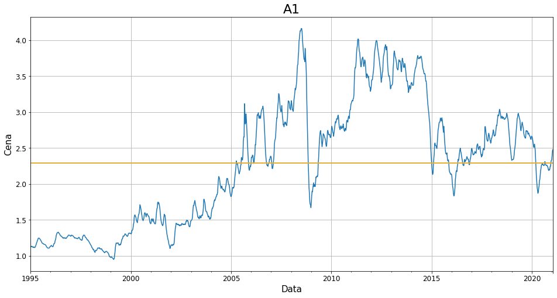

```python
#dane.A1.plot()
dane.A1.plot(figsize=(16, 8))

plt.title(label='A1', fontsize=22, color="black")

plt.xticks(fontsize=12)
plt.yticks(fontsize=12)

plt.xlabel("Data", fontsize=15)
plt.ylabel("Cena", fontsize=15)

plt.axhline(y=2.29, color='#e3af34', linestyle='-', linewidth=2) # 2.29 =  średnia dla A1
#plt.axhline(y=3.0, color='red', linestyle='-', linewidth=4)

plt.grid()
```

### Wykres 2020r.

```python
wykres20 = dane[['A1', 'rok']]
wykres20
```

| Date | A1 | rok |
| --- | --- | --- |
| 1995-01-02 | 1.127 | 1995 |
| 1995-01-09 | 1.134 | 1995 |
| 1995-01-16 | 1.126 | 1995 |
| 1995-01-23 | 1.132 | 1995 |
| 1995-01-30 | 1.131 | 1995 |
| ... | ... | ... |
| 2020-12-28 | 2.330 | 2020 |
| 2021-01-04 | 2.336 | 2021 |
| 2021-01-11 | 2.403 | 2021 |
| 2021-01-18 | 2.464 | 2021 |
| 2021-01-25 | 2.478 | 2021 |

1361 rows × 2 columns

```python
wykres20 = wykres20.loc['2020']
wykres20.head(3)
```

| Date | A1 | rok |
| --- | --- | --- |
| 2020-01-06 | 2.665 | 2020 |
| 2020-01-13 | 2.657 | 2020 |
| 2020-01-20 | 2.625 | 2020 |

```python
# 52.14 = 365/7 - zgadza sie (są wszystkie tygodnie z 2020 roku)
wykres20.shape
```

```
(52, 2)
```

```python
# średnia A1 dla 2020 roku
import statistics

statistics.mean(wykres20.A1)
```

```
2.25825
```

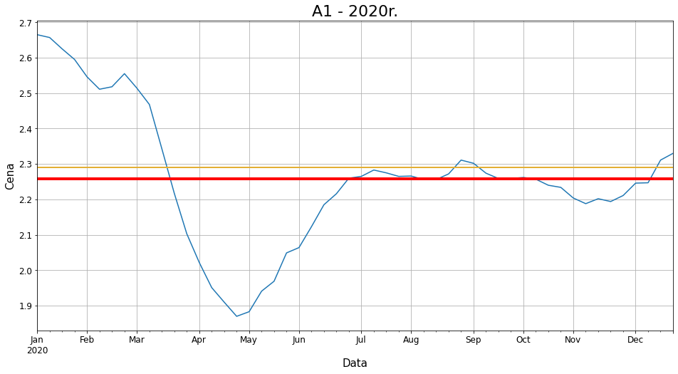

```python
#dane.A1.plot()
wykres20.A1.plot(figsize=(16, 8))

plt.title(label='A1 - 2020r.', fontsize=22, color="black")

plt.xticks(fontsize=12)
plt.yticks(fontsize=12)

plt.xlabel("Data", fontsize=15)
plt.ylabel("Cena", fontsize=15)

plt.axhline(y=2.29, color='#e3af34', linestyle='-', linewidth=2) # średnia dla 1995-2021
plt.axhline(y=2.25825, color='red', linestyle='-', linewidth=4) # srednia dla 2020 roku

plt.grid()
```

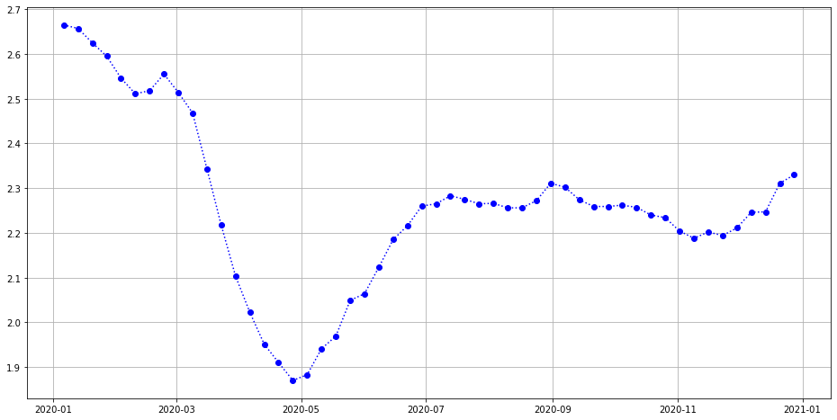

```python
ypoints = wykres20.A1

plt.figure(figsize=(16, 8))

plt.plot( ypoints, 'o:b' , ms=6) # o - symbol, : - linia,  b - blue, ms = rozmiar symbolu

plt.grid()

plt.show()
```

### 4 Wykresy (można wyświetlać 'dane.A1' albo 'wykres20.A1')

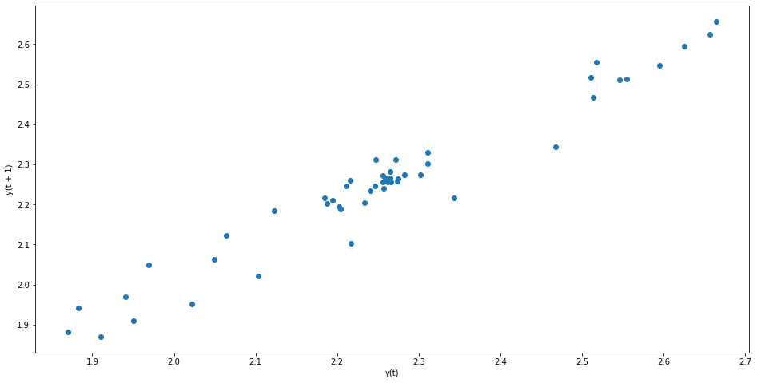

```python
from pandas.plotting import lag_plot
plt.figure(figsize=(16, 8))
lag_plot(wykres20.A1)
```

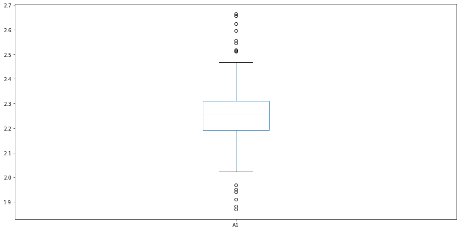

```python
plt.figure(figsize=(16, 8))
wykres20.A1.plot(kind='box')
```

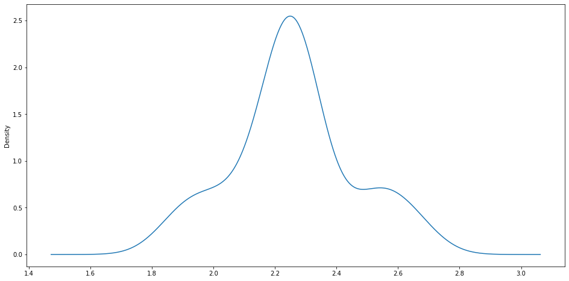

```python
plt.figure(figsize=(16, 8))
wykres20.A1.plot(kind='kde')
```

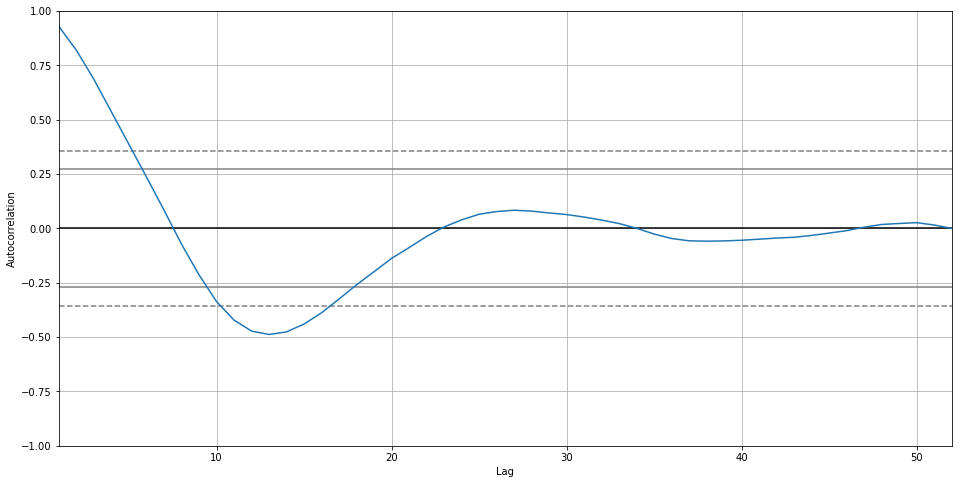

```python
from pandas.plotting import autocorrelation_plot
plt.figure(figsize=(16, 8))
autocorrelation_plot(wykres20.A1)
```

# Próbkowanie ziarnistości

- upsampling
- downsampling

```python
ZbiorDzienny=wykres20.A1.resample('D').mean()
ZbiorDzienny
```

```
Date
2020-01-06    2.665
2020-01-07      NaN
2020-01-08      NaN
2020-01-09      NaN
2020-01-10      NaN
              ...
2020-12-24      NaN
2020-12-25      NaN
2020-12-26      NaN
2020-12-27      NaN
2020-12-28    2.330
Freq: D, Name: A1, Length: 358, dtype: float64
```

```python
ZbiorDzienny.isnull().sum()
```

```
306
```

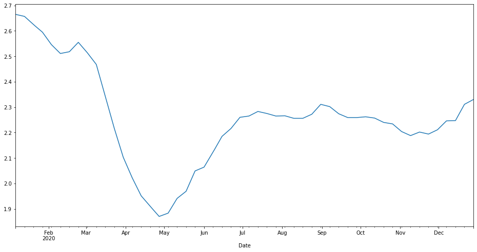

```python
ZbiorDzienny=wykres20.A1.resample('D').mean()
Pelny=ZbiorDzienny.interpolate(method='linear')
plt.figure(figsize=(16, 8))
Pelny.plot()
```

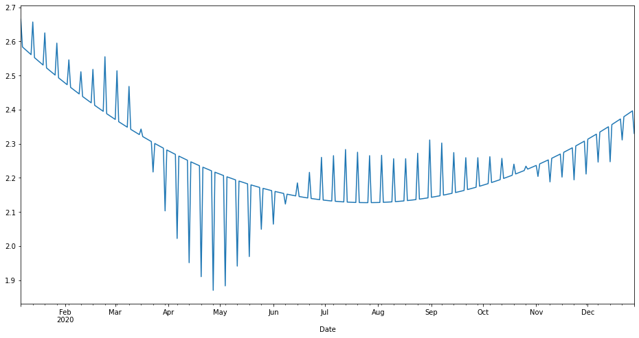

```python
ZbiorDzienny=wykres20.A1.resample('D').mean()
Pelny=ZbiorDzienny.interpolate(method='spline',order=2)
plt.figure(figsize=(16, 8))
Pelny.plot()
```

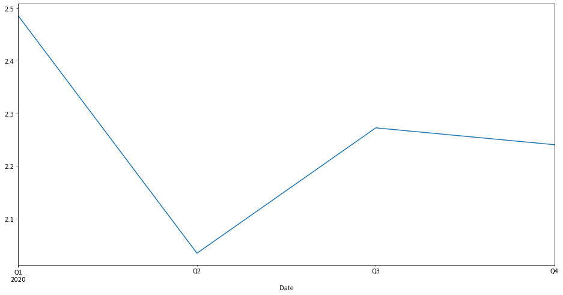

```python
ZbiorDzienny=wykres20.A1.resample('Q').mean()
Pelny=ZbiorDzienny.interpolate(method='spline',order=2)
plt.figure(figsize=(16, 8))
Pelny.plot()
```

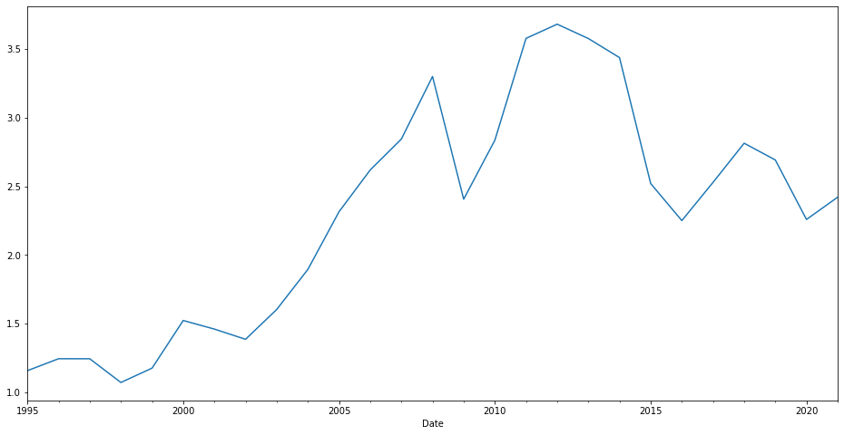

```python
ZbiorDzienny=dane.A1.resample('A').mean()
Pelny=ZbiorDzienny.interpolate(method='spline',order=2)
plt.figure(figsize=(16, 8))
Pelny.plot()
```